# DV_A2_Ming_Nie_mn2984

Ming Nie

3/15/2021

```r
data = read.csv("data/parking/parkingNYC_Jan2020-Jan2021.csv")
```

1. Violation Code and Fine Amounts Add the violation code descriptions and fine amounts to the data file.

```r
library(readxl)
vio_code <- read_excel("ParkingViolationCodes_January2020.xlsx")
names(vio_code)[1] <- "Violation.Code"
names(vio_code)[2] <- "Violation.Description"
names(vio_code)[3] <- "fine"
vio_code_1 <- select(vio_code,Violation.Code, Violation.Description, fine)
```

```r
df_1 <- left_join(data,vio_code_1, by = c ("Violation.Code"= "Violation.Code"))
df <- rename(df_1, c("Violation.Description.y" = "Description" ))
head(df,10)
```

```
##    Summons.Number Plate.ID Registration.State Plate.Type Issue.Date
## 1      1474094223  KDT3875                 NY        PAS 06/24/2020
## 2      1474094600  GTW5034                 NY        PAS 06/26/2020
## 3      1474097807  JEF4856                 NY        PAS 06/26/2020
## 4      1474097832  HKR3624                 NY        PAS 06/19/2020
## 5      1474100089  HJZ0180                 PA        PAS 06/22/2020
## 6      1474100090  HJZ0180                 PA        PAS 06/22/2020
## 7      1474101926  JKJ6877                 NY        PAS 07/01/2020
## 8      1474101940  JPT7536                 NY        PAS 06/27/2020
## 9      1474102207  GBX6525                 NY        PAS 06/27/2020
## 10     1474104060  KZJ9685                 PA        PAS 05/13/2020
##    Violation.Code Vehicle.Body.Type Vehicle.Make Issuing.Agency Street.Code1
## 1              98               SDN          KIA              P            0
## 2              20               SDN        VOLKS              P        18390
## 3              20               SDN        ME/BE              P        35710
```

[output cut: 117 more lines]

Provide a visual overview of the top 10 most common types of violations (feel free to group them into categories if reasonable). Compare how this ranking differs if we focus on the total amount of revenue generated.

```r
data_top10 <- df %>% group_by(Violation.Code)%>%
dplyr::summarise(count = n()) %>%
    top_n(10)
data_top10 <-left_join(data_top10,vio_code_1, by = c ("Violation.Code"= "Violation.Code"))

data_top10_rev <- df %>% filter(!is.na(fine)) %>% group_by(Violation.Code)%>%
  summarise_at(vars(fine),list(total= sum)) %>%
    top_n(10)
data_top10_rev <-left_join(data_top10_rev,vio_code_1, by = c ("Violation.Code"= "Violation.Code"))
```

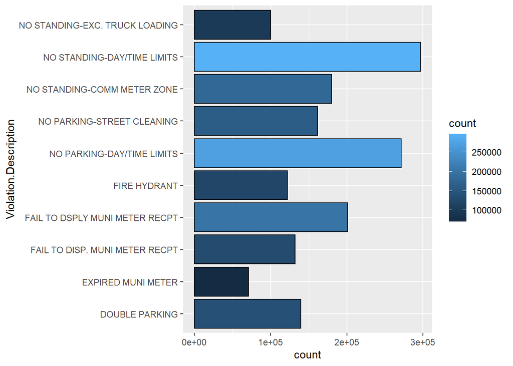

```r
ggplot(data_top10, aes(x = Violation.Description, y = count)) +
  geom_bar(color = "black", stat = "identity", aes(fill= count))+
  coord_flip()
```

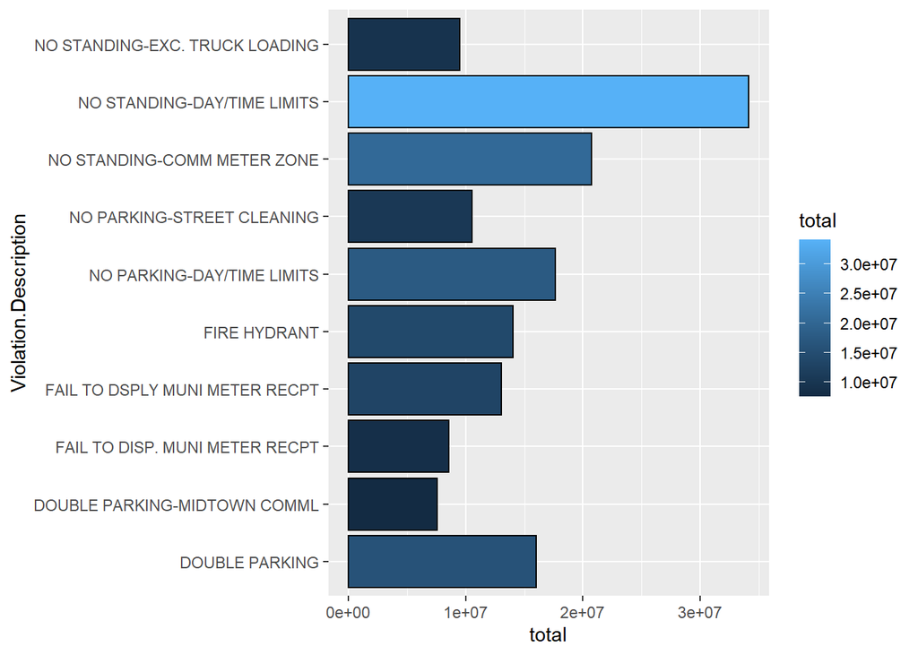

```r
ggplot( data_top10_rev, aes(x = Violation.Description, y = total)) +
  geom_bar(color = "black", stat = "identity", aes( fill= total))+
  coord_flip()
```

2. Average amount of fine by vehicle Compare the average amount of fine by vehicle color, vehicle year, and vehicle plate type [Hint: it is sufficient to restrict your attention to commercial (COM) and passenger (PAS) vehicles]? Briefly describe your findings.

```r
df %>% filter(!is.na(fine)) %>% group_by(Vehicle.Color)%>% summarise_at(vars(fine),list(ave = mean)) %>% arrange(desc(ave))
```

```
## # A tibble: 248 x 2
##    Vehicle.Color   ave
##    <chr>         <dbl>
##  1 SV              180
##  2 WH/BL           165
##  3 TEAL            130
##  4 B L             115
##  5 BAIGE           115
##  6 BBRW            115
##  7 BERG            115
##  8 BGE             115
##  9 BIERG           115
## 10 BKJ             115
## # ... with 238 more rows
```

```r
df %>% filter(!is.na(fine)) %>% group_by(Vehicle.Year)%>% summarise_at(vars(fine),list(ave = mean)) %>% arrange(desc(ave))
```

```
## # A tibble: 77 x 2
##    Vehicle.Year   ave
##           <int> <dbl>
##  1         2028 115
##  2         2040 115
##  3         2041 115
##  4         2056 115
##  5         2060 115
##  6         2069 105
##  7         2066 102.
##  8         1997  99.2
##  9         1990  98.1
## 10         2063  98
## # ... with 67 more rows
```

```r
df %>% filter(!is.na(fine)) %>% group_by(Plate.Type)%>% summarise_at(vars(fine),list(ave = mean)) %>% arrange(desc(ave))
```

```
## # A tibble: 72 x 2
##    Plate.Type   ave
##    <chr>      <dbl>
##  1 BOT         115
##  2 CBS         115
##  3 CCK         115
##  4 FAR         115
##  5 HOU         115
##  6 JCA         115
##  7 OMF         115
##  8 USC         115
##  9 AGC         111.
## 10 PSD         106.
## # ... with 62 more rows
```

3. Effect of COVID Let’s see if we can observe the effect of COVID restrictions on parking violations. Present a visualization that shows how parking violations changed after the New York statewide stay-at-home order on March 14, 2020. Make sure the visualization clearly highlights the main pattern (the COVID effect).

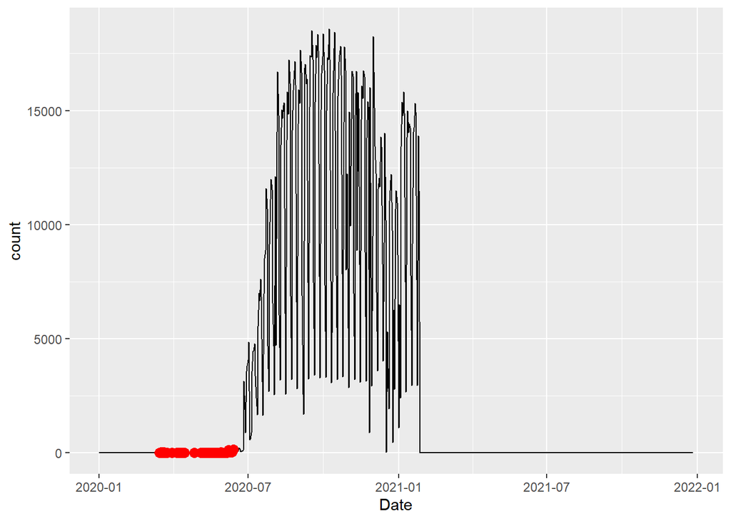

```r
data_covid <- df %>% group_by(Issue.Date) %>% dplyr::summarise(count=n())
data_covid$Date <-as.Date(data_covid$Issue.Date,"%m/%d/%Y")

highlight_max <- data_covid %>%
filter(Date > "2020-03-14" & Date <"2020-06-14")

ggplot(data = data_covid, aes(x = Date, y = count))+
  geom_line()+
  geom_point(data=highlight_max, aes(x = Date, y = count), color='red',size=3)+ theme(legend.position = "none")
```

2. Map by Precincts Read in the shape files for the police precincts and remove all precincts outside of Manhattan.

```r
library(rgdal)
nypd <- readOGR(dsn = "data/police_precincts", layer = "nypp")
library(spdplyr)
nypd <- nypd %>% dplyr::filter(Precinct<=34)
```

1. Number of tickets, total fines, and average fines Provide three maps that show choropleth maps of:

the total number of tickets

```r
df <- df %>% dplyr::filter(Issuer.Precinct<=34)
tmap_mode("view")
```

```
## tmap mode set to interactive viewing
```

```r
data_a1 <- df %>% group_by(Issuer.Precinct) %>% dplyr::summarise(total_ticket=n())
nypd_a1 <- left_join(nypd,data_a1, by = c("Precinct"= "Issuer.Precinct" ))
tm_shape(nypd_a1) + tm_borders()+ tm_fill("total_ticket")
```

[interactive chart not shown]

the total amount of fines

```r
df_fine <- df %>%
    select(Issuer.Precinct, fine)

sum_fine <- df_fine %>% filter(!is.na(fine)) %>% group_by(Issuer.Precinct)%>%
  summarise_at(vars(fine),list(total= sum, ave = mean))

sum_fine
```

```
## # A tibble: 34 x 3
##    Issuer.Precinct    total   ave
##  *           <int>    <dbl> <dbl>
##  1               1 14929330  90.1
##  2               2   214085 101.
##  3               3   286225  91.8
##  4               4   217840  88.3
##  5               5  7899305  84.8
##  6               6 10181630  81.4
##  7               7  5133310  82.9
##  8               8     1135  87.3
##  9               9  8285770  86.1
## 10              10 11197705  90.3
## # ... with 24 more rows
```

```r
tmap_mode("view")
```

```
## tmap mode set to interactive viewing
```

```r
nypd_fine <- left_join(nypd,sum_fine, by = c("Precinct"= "Issuer.Precinct" ))
tm_shape(nypd_fine) + tm_borders()+ tm_fill("total")
```

[interactive chart not shown]

the average amount of fines

```r
tm_shape(nypd_fine) + tm_borders()+ tm_fill("ave")
```

[interactive chart not shown]

2. Types of violations Group the almost 100 types of ticket violations into a smaller set of 4-6 subgroups (where other should be the remainder of violations not included in other groups you defined). [Hint: No need to spend more than 5 minutes thinking about what the right grouping is.]. Provide choropleth maps for each of these subgroups to show where different types of violations are more or less common.

Group1: top issues related to lane

```r
tmap_mode("view")
```

```
## tmap mode set to interactive viewing
```

```r
data_b1 <- df %>% filter(Violation.Code==5| Violation.Code==12| Violation.Code==18| Violation.Code==41| Violation.Code==45| Violation.Code==48)%>% group_by(Issuer.Precinct)%>% dplyr::summarise(total_lane = n())
nypd_b1 <- merge(nypd, data_b1, by.x="Precinct", by.y = "Issuer.Precinct" )
tm_shape(nypd_b1) + tm_borders()+ tm_fill("total_lane")
```

[interactive chart not shown]

Group2: top 5 expensive fine type

```r
tmap_mode("view")
```

```
## tmap mode set to interactive viewing
```

```r
data_b2 <- df %>% filter(Violation.Code==2| Violation.Code==3| Violation.Code==4| Violation.Code==29| Violation.Code==30)%>% group_by(Issuer.Precinct)%>% dplyr::summarise(total = n())
nypd_b2 <- merge(nypd, data_b2, by.x="Precinct", by.y = "Issuer.Precinct" )
tm_shape(nypd_b2) + tm_borders()+ tm_fill("total")
```

[interactive chart not shown]

3. Focus on the Upper East Precinct 19 identifies the Upper East Side. The data currently does not provide latitude and longitude of the violation locations (and I am not sure what these street_code variables are for).

```r
library(leaflet)
register_google(key = "AIzaSyAZR98v6UwpaGNZJi3i8iwotGG9vKl5VME")
```

1. Ignoring fire hydrants Restrict your data to parking violations related to fire hydrants (Violation Code = 40). Using the variables Street Name and House Number as well as the knowledge that these addresses are in the Upper East Side of Manhattan, geocode at least 500 addresses. Include a data table of these addresses and the latitude and longitude of these addresses in the output.

```r
east <- df %>% filter(Violation.Code==40 & Violation.Precinct == 19)
loca <- east %>% sample_n(550)
geo <- geocode(paste(loca$House.Number, loca$Street.Name," , new york"))
```

```
## "S E 96th St  , ne..." not uniquely geocoded, using "e 96th st, new york, ny, usa"
```

```
## "N E 100th St  , n..." not uniquely geocoded, using "w 100th st, new york, ny 10025, usa"
```

```
## "N E 95th St  , ne..." not uniquely geocoded, using "w 95th st, new york, ny 10025, usa"
```

```
## "E 3rd Ave  , new ..." not uniquely geocoded, using "e 3rd st, new york, ny, usa"
```

```
## "E 3rd Ave  , new ..." not uniquely geocoded, using "e 3rd st, new york, ny, usa"
```

```
## "N E 95th St  , ne..." not uniquely geocoded, using "w 95th st, new york, ny 10025, usa"
```

```
## "N E 95th St  , ne..." not uniquely geocoded, using "w 95th st, new york, ny 10025, usa"
```

```
## "N E 95th St  , ne..." not uniquely geocoded, using "w 95th st, new york, ny 10025, usa"
```

```r
loca_geo = data.frame(loca,geo)
```

2. Interactive Map Provide an interactive map of the violations you geocoded using leaflet. Provide at least three pieces of information on the parking ticket in a popup.

```r
m <- leaflet(loca_geo) %>%
  addTiles() %>%
  addCircles(lng = ~lon, lat = ~lat)

content <- paste("ID",loca_geo$Plate.ID,"<br/>",
                 "Issue Date",loca_geo$Issue.Date,"<br/>",
                 "Registration State",loca_geo$Registration.State,"<br/>")
(mpop2 <- m %>% addCircles( popup = content))
```

```
## Assuming "lon" and "lat" are longitude and latitude, respectively
```

[interactive chart not shown]

3. Luxury cars and repeat offenders Using the vehicle Plate ID, identify repeat offenders (in the full dataset). Create another variable called luxury_car in which you identify luxury car brands using the Vehicle Make variable.

Start with the previous map. Distinguish the points by whether the car is a repeat offender and/or luxury car. Add a legend informing the user about the color scheme. Also make sure that the added information about the car type and repeat offender status is now contained in the popup information. Show this map.

```r
df_count <- df %>% group_by(Plate.ID) %>% dplyr::summarise(count=n())
loca_geo  <- left_join(loca_geo , df_count, by = c ("Plate.ID"= "Plate.ID"))
```

```r
loca_geo1 <-loca_geo %>%  mutate(luxury_car = case_when(Vehicle.Make == "ROVER" ~ "luxury",
                                                        Vehicle.Make == "BMW" ~ "luxury",
                                Vehicle.Make == "LEXUS" ~ "luxury"))%>%
  mutate(lux_repeat= case_when(luxury_car == "luxury" ~ "1"))%>%
  mutate(lux_repeat = ifelse(count >1, 1,0))
head(loca_geo1,10)
```

```
##    Summons.Number Plate.ID Registration.State Plate.Type Issue.Date
## 1      8859210124   N69LSS                 NJ        PAS 01/04/2021
## 2      8778246520   C53EZS                 NJ        PAS 08/16/2020
## 3      8836702673  JAD2177                 NY        PAS 10/05/2020
## 4      8853890733  898522R                 NJ        PAS 01/15/2021
## 5      8792202410  JER1365                 NY        PAS 11/24/2020
## 6      8807964600  HWT4536                 NY        PAS 08/14/2020
## 7      8838022331  HGL4555                 NY        PAS 11/08/2020
## 8      8624686088  92975T1                 TX        PAS 11/30/2020
## 9      8854721955  JBW3689                 NY        PAS 12/26/2020
## 10     8786141314  86119MM                 NY        COM 07/03/2020
##    Violation.Code Vehicle.Body.Type Vehicle.Make Issuing.Agency Street.Code1
## 1              40              SUBN        ACURA              T        18410
## 2              40              SUBN         JEEP              T        24890
## 3              40              SUBN        TOYOT              T        18670
```

[output cut: 128 more lines]

```r
m2 <- leaflet(loca_geo1) %>%
  addTiles() %>%
  addCircles(lng = ~lon, lat = ~lat)

factpal <- colorFactor(topo.colors(2), loca_geo1$lux_repeat)

content <- paste("ID",loca_geo1$Plate.ID,"<br/>",
                 "Issue Date",loca_geo1$Issue.Date,"<br/>",
                 "Vehicle Make",loca_geo1$Vehicle.Make,"<br/>",
                 "luxury",loca_geo1$luxury_car,"<br/>",
                 "count",loca_geo1$count,"<br/>")
(mpop3 <- m2 %>% addCircles(color= ~factpal(lux_repeat),  popup = content))
```

```
## Assuming "lon" and "lat" are longitude and latitude, respectively
```

[interactive chart not shown]

4. Cluster Add marker clustering, so that zooming in will reveal the individual locations but the zoomed out map only shows the clusters. Show the map with clusters.

```r
(mclust <- m2 %>% addCircleMarkers(color=loca_geo1$luxury_car, weight = loca_geo1$count, popup = content,clusterOptions = markerClusterOptions()))
```

```
## Assuming "lon" and "lat" are longitude and latitude, respectively
```

[interactive chart not shown]